# Coursera Data Products

## Linear Regression

Low Yi Xiang  
Data Scientist-Wannabe

## Data Product

1. Dashboard that allows user to upload a clean (csv) file.
2. The data used here is from mtcars - but it should be applicable to any data sets
3. The first 28 rows of mtcars is used as training data, and the last 4 is used for prediction.
4. Data and source code avaliable at: https://github.com/Freedom89/data_products

```r
#R codes
data(mtcars)
summary(mtcars)
```

```
##       mpg            cyl            disp             hp
##  Min.   :10.4   Min.   :4.00   Min.   : 71.1   Min.   : 52.0
##  1st Qu.:15.4   1st Qu.:4.00   1st Qu.:120.8   1st Qu.: 96.5
##  Median :19.2   Median :6.00   Median :196.3   Median :123.0
##  Mean   :20.1   Mean   :6.19   Mean   :230.7   Mean   :146.7
##  3rd Qu.:22.8   3rd Qu.:8.00   3rd Qu.:326.0   3rd Qu.:180.0
##  Max.   :33.9   Max.   :8.00   Max.   :472.0   Max.   :335.0
##       drat            wt            qsec            vs
##  Min.   :2.76   Min.   :1.51   Min.   :14.5   Min.   :0.000
##  1st Qu.:3.08   1st Qu.:2.58   1st Qu.:16.9   1st Qu.:0.000
##  Median :3.69   Median :3.33   Median :17.7   Median :0.000
##  Mean   :3.60   Mean   :3.22   Mean   :17.8   Mean   :0.438
##  3rd Qu.:3.92   3rd Qu.:3.61   3rd Qu.:18.9   3rd Qu.:1.000
##  Max.   :4.93   Max.   :5.42   Max.   :22.9   Max.   :1.000
##        am             gear           carb
##  Min.   :0.000   Min.   :3.00   Min.   :1.00
##  1st Qu.:0.000   1st Qu.:3.00   1st Qu.:2.00
##  Median :0.000   Median :4.00   Median :2.00
##  Mean   :0.406   Mean   :3.69   Mean   :2.81
##  3rd Qu.:1.000   3rd Qu.:4.00   3rd Qu.:4.00
##  Max.   :1.000   Max.   :5.00   Max.   :8.00
```

## Basic layout

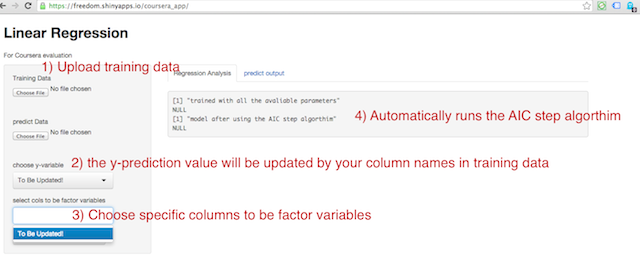

1. Upload the data set
2. You can choose the y-variable you want to predict. it is best to use the first column as the y-variable as that will be the default when it is updated
3. You can select which variable to be factor variable based on the col names

## Next Step

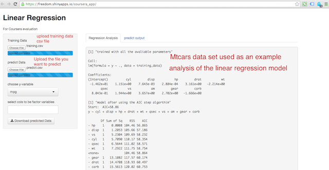

1. As stated, mtcars is used as an example and the data is avaliable in github
2. The dashboard auto computes the AIC and gives the optimal regression model

## features

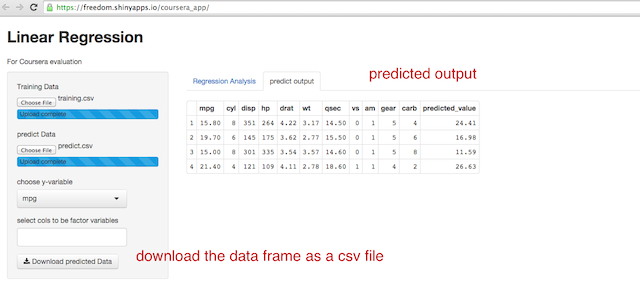

1. Quickview to see the predict data plus the predicted value
2. Easy to use - just have a csv file for training and one that you want to perform prediction
3. Download button avaliable.